# Project Python Foundations: FoodHub Data Analysis

# Observation

- Food Preparation time first quartile is at 23
- Third quartile is at 31
- Median being at 27
- No Outliers are seen

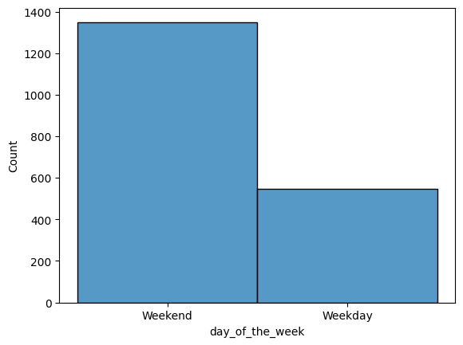

```python
sns.histplot(data=df, x='day_of_the_week');
```

#### Observation

- Orders are high during weekends than weekdays

```python
df['day_of_the_week'].value_counts()
```

| day_of_the_week | count |
| --- | --- |
| Weekend | 1351 |
| Weekday | 547 |

**dtype:** int64

```python
df.groupby('day_of_the_week')['cuisine_type'].value_counts()
```

| day_of_the_week | cuisine_type | count |
| --- | --- | --- |
| Weekday | American | 169 |
|  | Japanese | 135 |
|  | Italian | 91 |
|  | Chinese | 52 |
|  | Indian | 24 |
|  | Mexican | 24 |
|  | Middle Eastern | 17 |
|  | Mediterranean | 14 |
|  | Southern | 6 |
|  | French | 5 |
|  | Thai | 4 |
|  | Vietnamese | 3 |
|  | Korean | 2 |
|  | Spanish | 1 |
| Weekend | American | 415 |
|  | Japanese | 335 |
|  | Italian | 207 |
|  | Chinese | 163 |
|  | Mexican | 53 |
|  | Indian | 49 |
|  | Mediterranean | 32 |
|  | Middle Eastern | 32 |
|  | Thai | 15 |
|  | French | 13 |
|  | Korean | 11 |
|  | Southern | 11 |
|  | Spanish | 11 |
|  | Vietnamese | 4 |

**dtype:** int64

#### Oberservation

- Whether its weekday or weekend American food is most preferred
- For every cuisine orders increase during the weekends

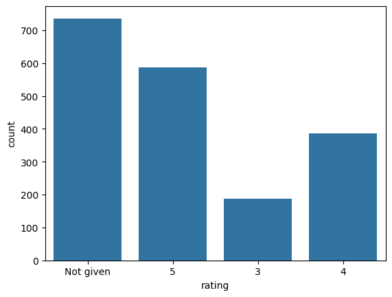

```python
sns.countplot(data=df, x='rating');
```

```python
No_rating = df['rating']=='Not given'
No_rating.sum()
```

```
np.int64(736)
```

### Observation:

736 orders have not been given any rating out 1898 orders

```python
df['customer_id'].nunique()
```

```
1200
```

```python
df['customer_id'].value_counts().unique()
```

```
array([13, 10,  9,  8,  7,  6,  5,  4,  3,  2,  1])
```

#### Observation

- There are 1200 customers of Foodhub.
- Min number of orders per customer id is 1
- Max number of order per customer id is 13

```python
number_of_orders=df['customer_id'].value_counts()
order_dataframe=pd.DataFrame(number_of_orders)
order_dataframe.value_counts()
```

| count | count |
| --- | --- |
| 1 | 784 |
| 2 | 267 |
| 3 | 83 |
| 4 | 33 |
| 5 | 19 |
| 6 | 6 |
| 7 | 4 |
| 8 | 1 |
| 9 | 1 |
| 10 | 1 |
| 13 | 1 |

**dtype:** int64

#### Observation:

- Max customers of food hub (784) place single order

### **Question 7**: Which are the top 5 restaurants in terms of the number of orders received? [1 mark]

```python
# Write the code here
df['restaurant_name'].value_counts().sort_values(ascending=False).head(5)
```

| restaurant_name | count |
| --- | --- |
| Shake Shack | 219 |
| The Meatball Shop | 132 |
| Blue Ribbon Sushi | 119 |
| Blue Ribbon Fried Chicken | 96 |
| Parm | 68 |

**dtype:** int64

```python
top5restuarant = df['restaurant_name'].value_counts().head(5)
top5restuarant.sum()
```

```
np.int64(634)
```

#### Observations:

- Top five restaurants with foodhub are
  - Shake Shack
  - The Meatball Shop
  - Blue Ribbon Sushi
  - Blue Ribbon Fried Chicken
  - Parm
- A total of 634 orders were given by top 5 restaurant
- Shake Shack had max orders of 219

### **Question 8**: Which is the most popular cuisine on weekends? [1 mark]

```python
# Write the code
df_weekend = df[df['day_of_the_week'] == 'Weekend']
df_weekend['cuisine_type'].value_counts().sort_values(ascending=False).head(1)
```

| cuisine_type | count |
| --- | --- |
| American | 415 |

**dtype:** int64

#### Observations:

- American was most popular cuisine over the weekend. Total number of order recieved for American cuisine was 415
- American cuisine recieved 80 more orders than second most ordered cuisine

### **Question 9**: What percentage of the orders cost more than 20 dollars? [2 marks]

```python
# Write the code here
df_greater_than_20 = df[df['cost_of_the_order']>20] #get the orders dataframe for orders more than 20
total_order_greater_than_20 = df_greater_than_20.shape[0]/df.shape[0]*100 #calculate percentage
print(f'{total_order_greater_than_20:.2f}% of the orders cost more than 20 dollars') #print the value
```

```
29.24% of the orders cost more than 20 dollars
```

#### Observations:

Only 29.24% orders cost more than 20 dollars

### **Question 10**: What is the mean order delivery time? [1 mark]

```python
# Write the code
mean_delivery_time = df['delivery_time'].mean()
print(f'The mean order delivery time is {mean_delivery_time:.2f} minutes')
```

```
The mean order delivery time is 24.16 minutes
```

#### Observations:

- The mean order delivery time is 24.16 min

### **Question 11:** The company has decided to give 20% discount vouchers to the top 3 most frequent customers. Find the IDs of these customers and the number of orders they placed. [1 mark]

```python
# Write the code here
df['customer_id'].value_counts().sort_values(ascending=False).head(3)
```

| customer_id | count |
| --- | --- |
| 52832 | 13 |
| 47440 | 10 |
| 83287 | 9 |

**dtype:** int64

#### Observations:

Customer ids 52832,47440 and 83287 should be given 20% percent discount as they are the top 3 frequent customer ids.

### **Question 12**: Perform a multivariate analysis to explore relationships between the important variables in the dataset. (It is a good idea to explore relations between numerical variables as well as relations between numerical and categorical variables) [10 marks]

```python
numerical_features = df.select_dtypes(include=np.number).columns
df[numerical_features].corr()
```

|  | order_id | customer_id | cost_of_the_order | food_preparation_time | delivery_time |
| --- | --- | --- | --- | --- | --- |
| order_id | 1.000000 | -0.013960 | 0.021171 | -0.007026 | 0.009690 |
| customer_id | -0.013960 | 1.000000 | -0.001322 | -0.030330 | -0.009885 |
| cost_of_the_order | 0.021171 | -0.001322 | 1.000000 | 0.041527 | -0.029949 |
| food_preparation_time | -0.007026 | -0.030330 | 0.041527 | 1.000000 | 0.011094 |
| delivery_time | 0.009690 | -0.009885 | -0.029949 | 0.011094 | 1.000000 |

#### Observation

No significant relationship seen.

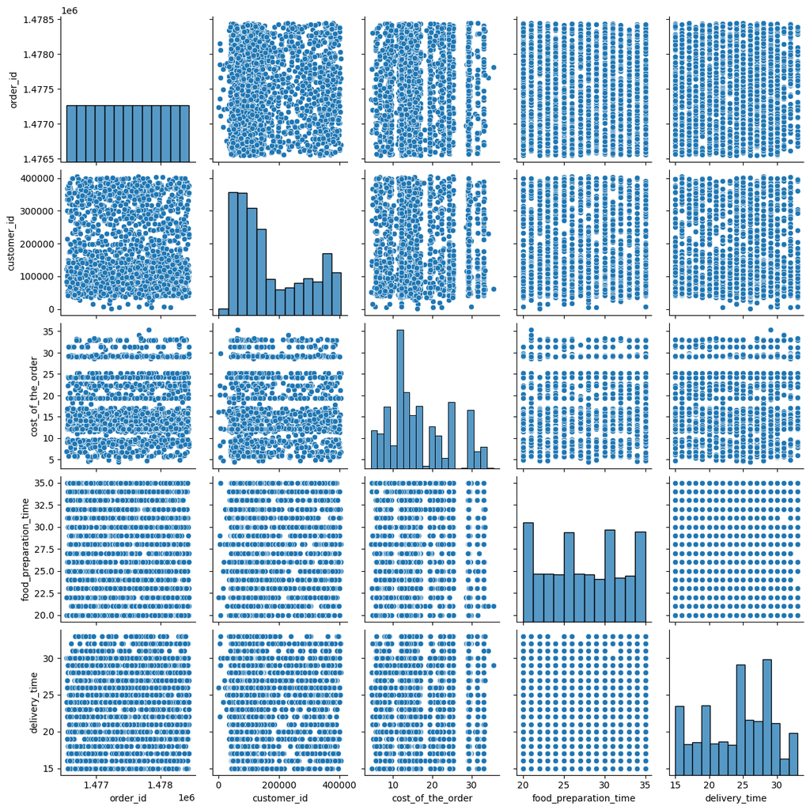

```python
sns.pairplot(data=df[numerical_features]);
```

#### Observation:

There is no linear relationship between variables

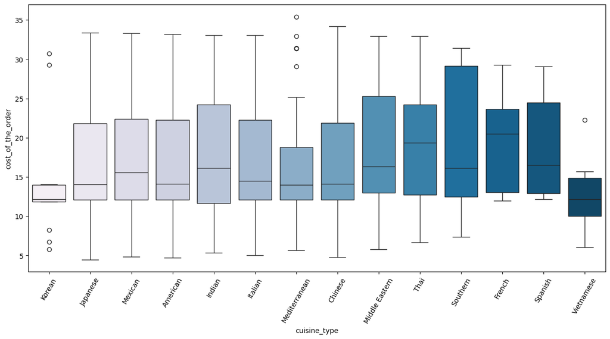

```python
# Write the code here
#Relationship between cusine type and cost of order
plt.figure(figsize=(15,7))
sns.boxplot(x = "cuisine_type", y = "cost_of_the_order", data = df,palette = 'PuBu',  hue = "cuisine_type")
plt.xticks(rotation = 60)
plt.show()
```

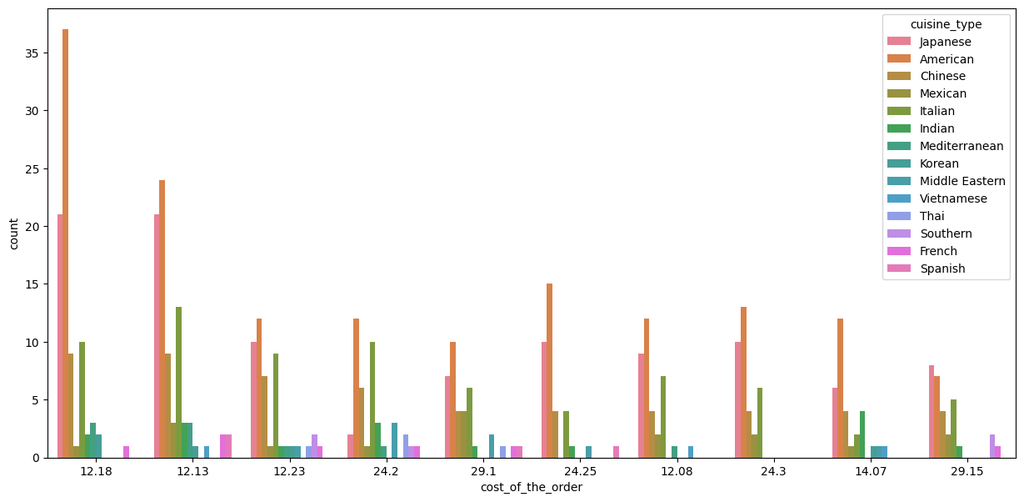

```python
plt.figure(figsize=(15,7))
sns.countplot(data=df, x = 'cost_of_the_order', hue = 'cuisine_type', order=df['cost_of_the_order'].value_counts().iloc[:10].index);
```

#### Observation

- Max number of orders is at the cost of 12.18
- American orders are max at this cost as well.
- Orders at 12.08 and 14.07 are not many hence can be looked at

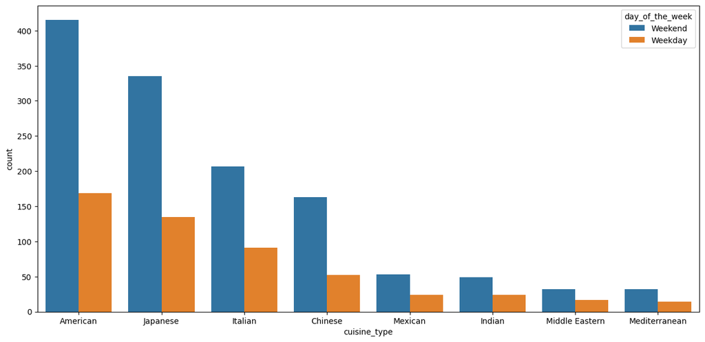

```python
plt.figure(figsize=(15,7))
sns.countplot(data=df, x = 'cuisine_type', hue = 'day_of_the_week', order=df['cuisine_type'].value_counts().iloc[:8].index);
```

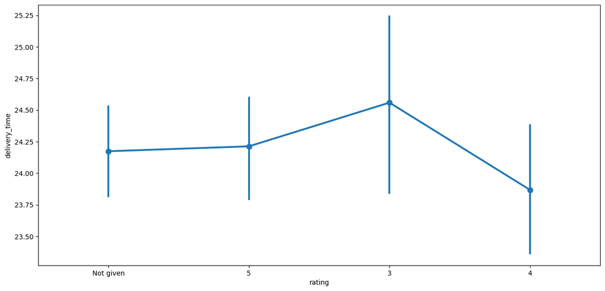

```python
plt.figure(figsize=(15, 7))
sns.pointplot(x = 'rating', y = 'delivery_time', data = df)
plt.show()
```

#### Observation

- Rating is 3 when average delivery time is around 24.50
- Rating is 4 when average delivery time is around 23.75
- Rating of 5 or not given is around the delivery time 24.15. This data should be looked at.

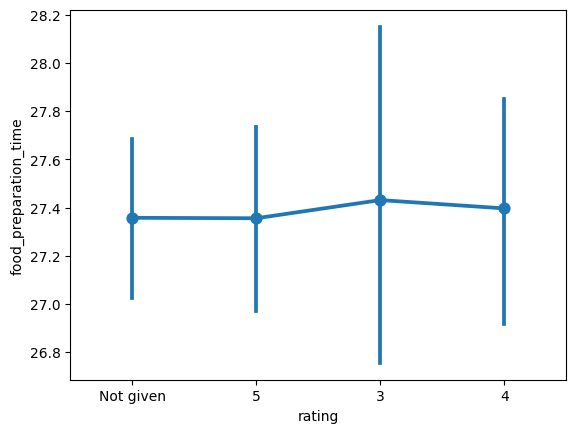

```python
sns.pointplot(x = 'rating', y = 'food_preparation_time', data = df)
plt.show()
```

#### Observation

- Rating is 3 when average food preparation time is around 27.4
- Rating is 4 when average food preparation time is between 27.2 and 27.4
- Rating of 5 or not given is around the delivery time 27.3. This data should be looked at.

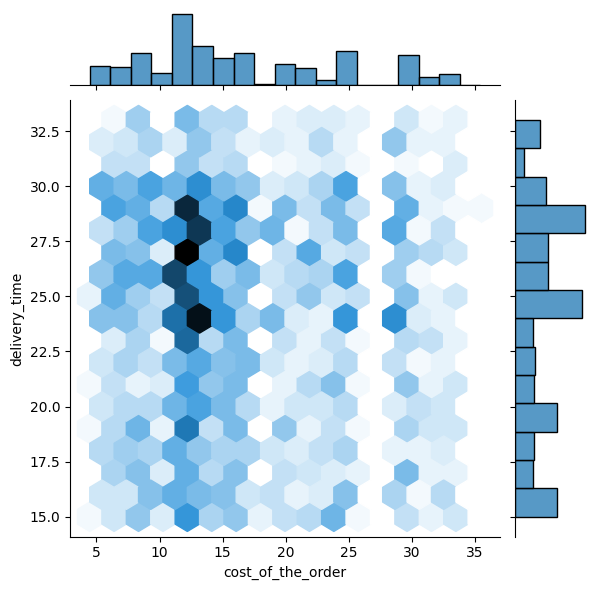

```python
sns.jointplot(data=df, x='cost_of_the_order', y='delivery_time', kind='hex');
```

#### Observation

- Max order are in range of 11 USD with a delivery time of aroud 24 to 30 min

### **Question 13:** The company wants to provide a promotional offer in the advertisement of the restaurants. The condition to get the offer is that the restaurants must have a rating count of more than 50 and the average rating should be greater than 4. Find the restaurants fulfilling the criteria to get the promotional offer. [3 marks]

```python
# Write the code here
df_rating_given = df[df['rating'] != 'Not given'].copy() #create a copy of the dataframe
df_rating_given['rating'] = df_rating_given['rating'].astype('int')# Convert rating column from object to integer
avg_ratings = df_rating_given.groupby('restaurant_name')['rating'].mean() #reset the index so that these restaurants can be further filtered based on average rating
df_rating_count = df_rating_given.groupby(['restaurant_name'])['rating'].count().sort_values(ascending = False).reset_index()# Create a dataframe that contains the restaurant names with their rating counts
avg_ratings = df_rating_given.groupby('restaurant_name')['rating'].mean().reset_index()
# Filter restaurants with an average rating > 4
high_avg_rating = avg_ratings[avg_ratings['rating'] > 4]
#Merging with the dataframe feilds to get only resturants who have number of ratings greater than 50 and rating mean greater 4
filtered_restaurants = df_rating_count[df_rating_count['rating'] > 50].merge(high_avg_rating,on='restaurant_name')
filtered_restaurants
```

|  | restaurant_name | rating_x | rating_y |
| --- | --- | --- | --- |
| 0 | Shake Shack | 133 | 4.278195 |
| 1 | The Meatball Shop | 84 | 4.511905 |
| 2 | Blue Ribbon Sushi | 73 | 4.219178 |
| 3 | Blue Ribbon Fried Chicken | 64 | 4.328125 |

#### Observations:

- There are only four restaurants which have ratings greater than 50 and ratings greater than 4
- Restaurant - The Meatball shop has the highest rating for 4.5

### **Question 14:** The company charges the restaurant 25% on the orders having cost greater than 20 dollars and 15% on the orders having cost greater than 5 dollars. Find the net revenue generated by the company across all orders. [3 marks]

```python
# Write the code
def compute_revenue(rev):
    if rev > 20:
        return rev*0.25
    elif rev > 5:
        return rev*0.15
    else:
        return rev*0

df['Revenue'] = df['cost_of_the_order'].apply(compute_revenue) ## Compute the revenue
total_revenue = df['Revenue'].sum()
format(total_revenue)
```

```
'6166.303'
```

#### Observations:

- The total revinew of the company is $6166.303

### **Question 15:** The company wants to analyze the total time required to deliver the food. What percentage of orders take more than 60 minutes to get delivered from the time the order is placed? (The food has to be prepared and then delivered.) [2 marks]

```python
# Write the code here
df['total_time'] = df['food_preparation_time'] + df['delivery_time']  #Calculate the total time from inception
total_order_greater_than_60 = df[df['total_time'] > 60].shape[0]  #find orders where total time is greater than 60 min
percentage_orders = (total_order_greater_than_60/ df['total_time'].shape[0])*100  #calculate percentage
percentage_orders
```

```
10.537407797681771
```

#### Observations:

- 10% of cuisines take more than 60 min to deliver from the time the order is placed

### **Question 16:** The company wants to analyze the delivery time of the orders on weekdays and weekends. How does the mean delivery time vary during weekdays and weekends? [2 marks]

```python
# Write the code here
print('The mean delivery time on weekdays is around',
      round(df[df['day_of_the_week'] == 'Weekday']['delivery_time'].mean()),
     'minutes')
print('The mean delivery time on weekends is around',
      round(df[df['day_of_the_week'] == 'Weekend']['delivery_time'].mean()),
     'minutes')
print('Mean delivery time is 6 min less in weekends than weekdays')
```

```
The mean delivery time on weekdays is around 28 minutes
The mean delivery time on weekends is around 22 minutes
Mean delivery time is 6 min less in weekends than weekdays
```

#### Observations:

- The mean delivery time on weekdays is around 28 minutes
- The mean delivery time on weekends is around 22 minutes
- Mean delivery time is 6 min less in weekends than weekdays

### Recommendations:

- `Customer feedback participation` As foodhub is customer delivery service its very important to know customer rating. High number of ratings not given does not add value to a customer centric business
  1. Offer incentives for feedback for delivery
  2. Offer incentives for feedback on food quality, taste, packaging
- `Orders on weekdays vs weekends` It has been observed during data analysis weekday orders for any cuisine type are much lesser than weekends. One of the suggestion is to give discounts on orders during weekdays and increase the prices during weekend so that customer base is developed during weekdays as well.
- `Cusine type` It has been observed that American cusine type is the most ordered. Other cuisine types can also be promoted to increase the revenue. Or find restaurants which have larger customer base with different cuisine.
- `Return Customer` The percentage of return customer/reorder has been been very less. Out of 1200 customers, 784 customers have used food hub app to order once. Company should evaluate strategy to build brand loyalty and increase return customer based
- `Restaurants` There are total of 178 restaurants. Shake Shack is the one which being used the most. Shake Shack gives more than 200 order. Top five restaurant have 634 orders out of 1898 orders Foodhub should check why other restaurants are not able to generate so much of orders.